# Untitled

# Visualization using boxplot to inspect outliers

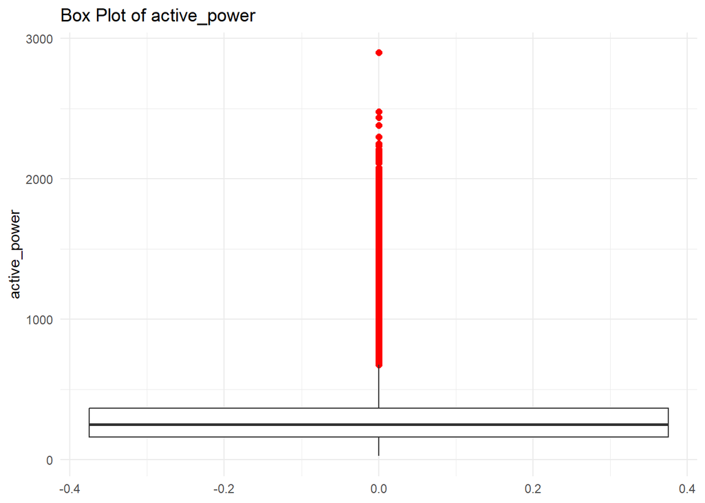

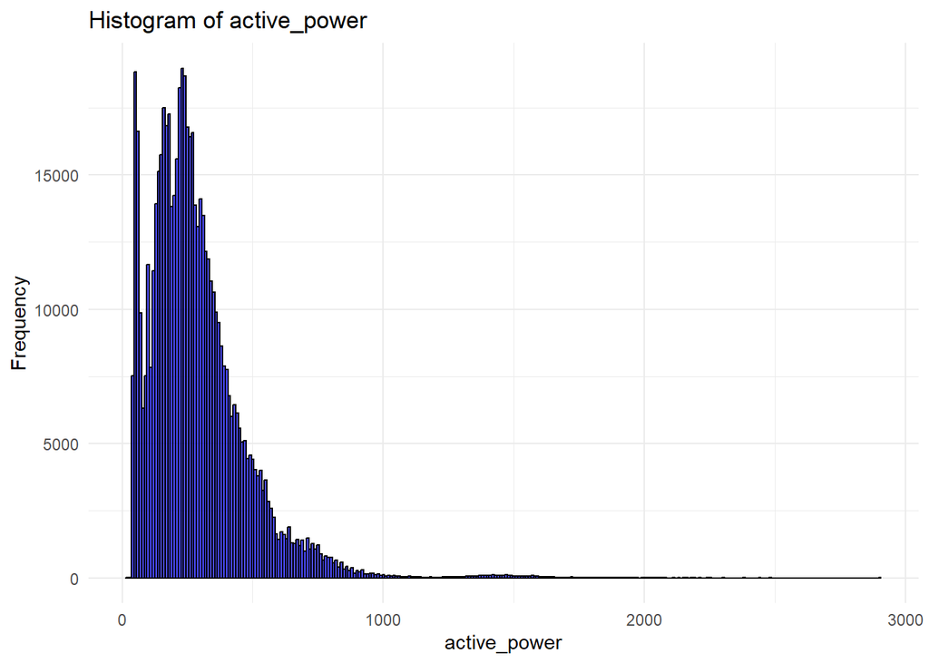

```r
create_plots <- function(data, feature_name) {
  # Box Plot
  box_plot <- ggplot(data, aes_string(y = feature_name)) +
    geom_boxplot(outlier.colour = "red", outlier.shape = 16, outlier.size = 2) +
    ggtitle(paste("Box Plot of", feature_name)) +
    ylab(feature_name) +
    theme_minimal()

  # Histogram
  hist_plot <- ggplot(data, aes_string(x = feature_name)) +
    geom_histogram(binwidth = 10, fill = "blue", color = "black", alpha = 0.7) +
    ggtitle(paste("Histogram of", feature_name)) +
    xlab(feature_name) +
    ylab("Frequency") +
    theme_minimal()

  # Print plots
  print(box_plot)
  print(hist_plot)
}

# Create visualizations for each feature
create_plots(energy, "active_power")
```

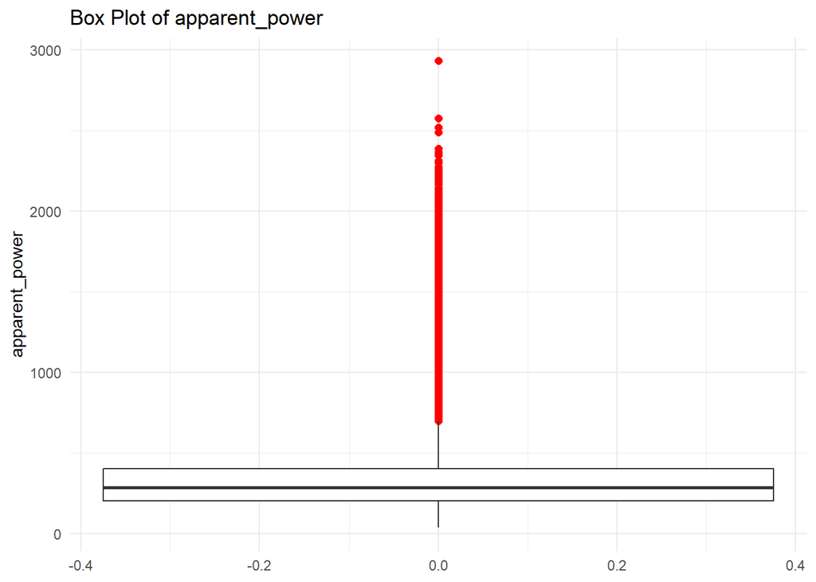

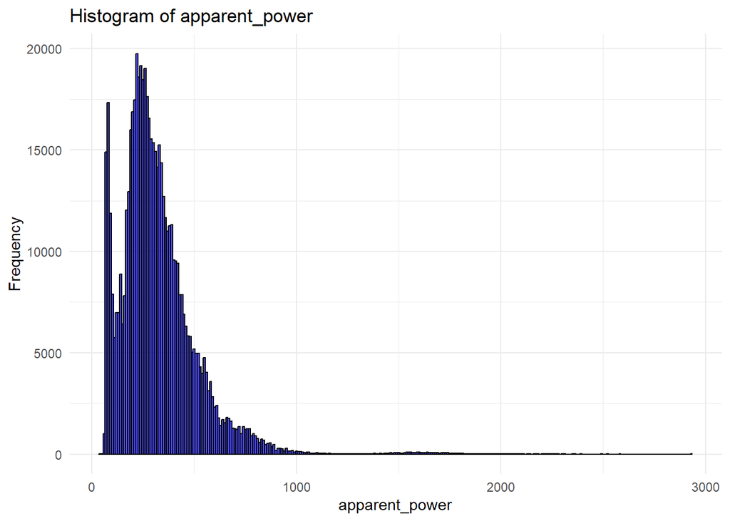

```r
create_plots(energy, "apparent_power")
```

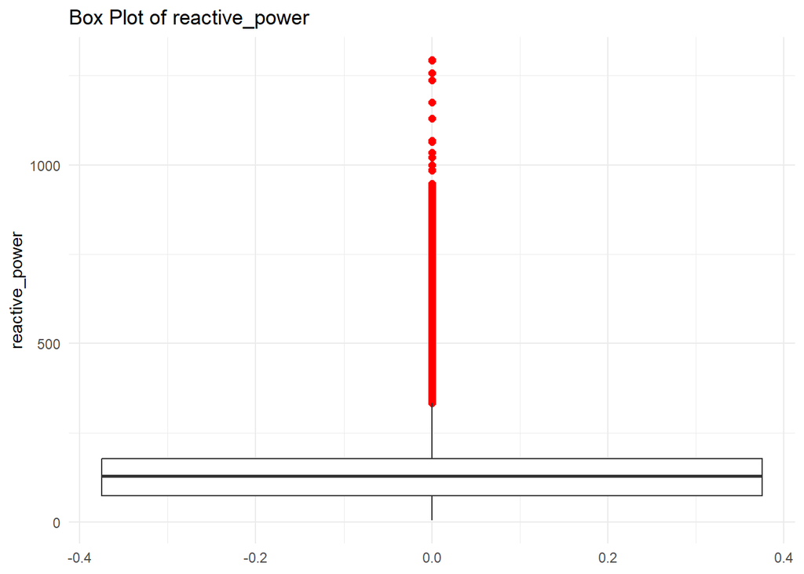

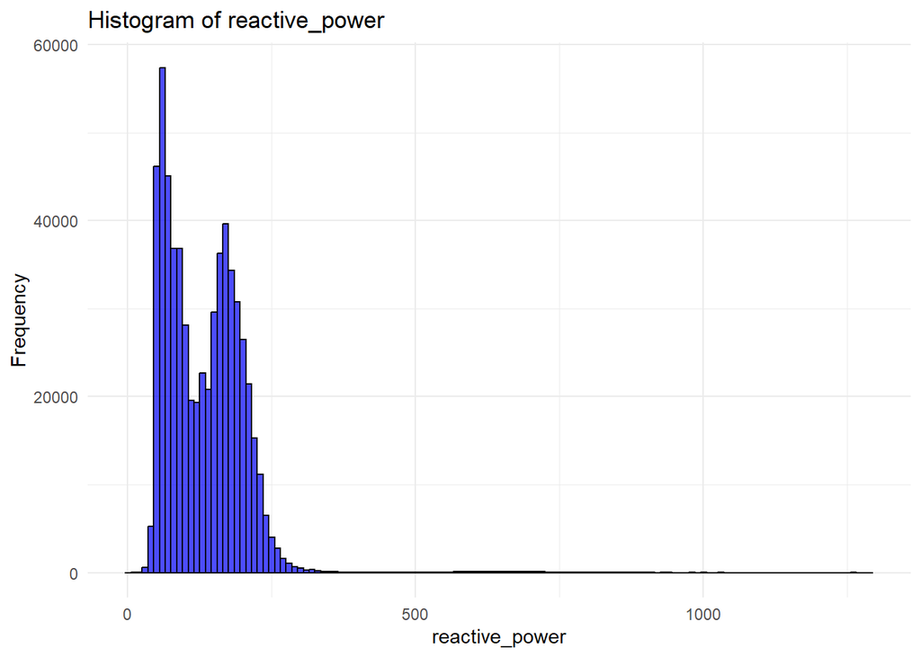

```r
create_plots(energy, "reactive_power")
```

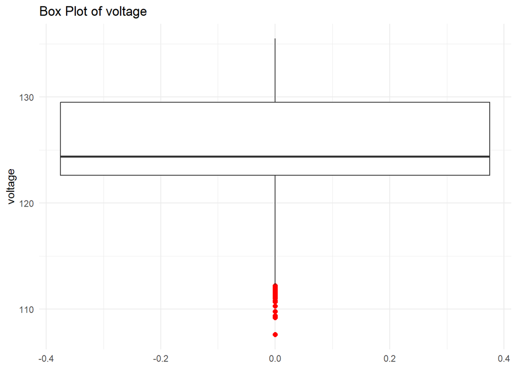

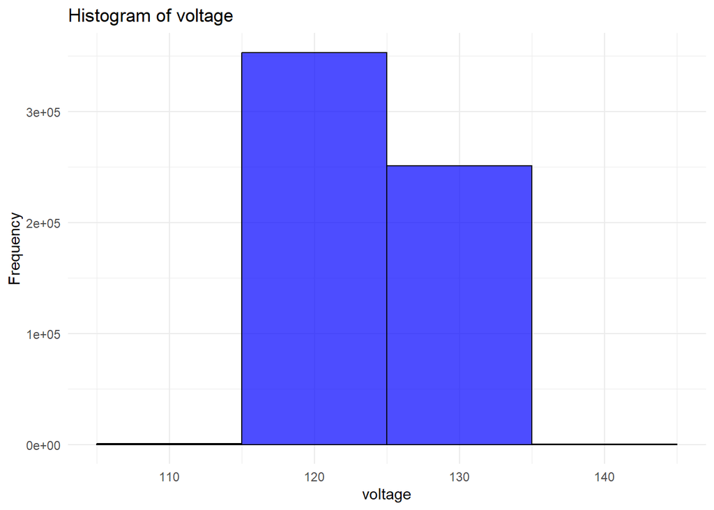

```r
create_plots(energy, "voltage")
```

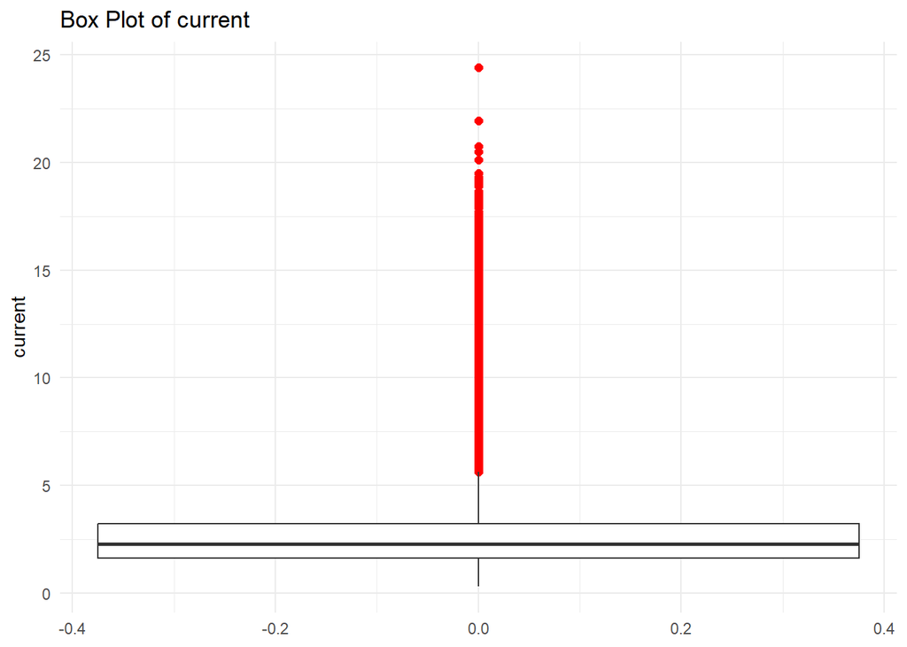

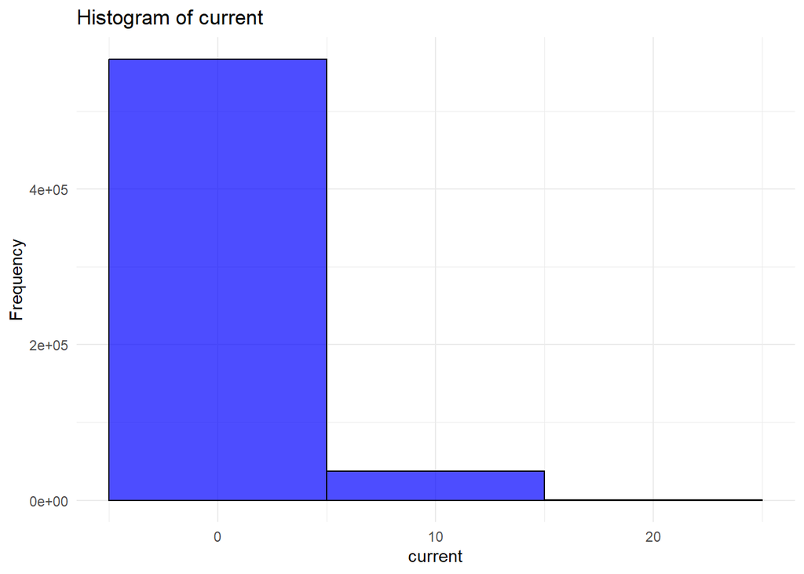

```r
create_plots(energy, "current")
```

Boxplots show the distribution of five electrical power variables: active power, apparent power, current, voltage, and reactive power. Active power, apparent power, reactive power, and current show a similar pattern, with most data points concentrated at lower values and outliers at higher values. The median is close to the bottom, suggesting low to moderate power levels. Voltage distribution is markedly different, with a well-defined central value and limited spread. Possible explanations include peak demand periods, equipment malfunctions, data recording errors, grid fluctuations, and equipment issues.

# Removing outliers from samples using Interquater range

```r
# List of numeric power variables
power_variables <- c("active_power", "reactive_power", "apparent_power", "voltage", "current")

# Function to remove outliers using the IQR method
remove_outliers_iqr <- function(data, columns) {
  data %>% mutate(across(all_of(columns), ~ {
    Q1 <- quantile(., 0.25, na.rm = TRUE)
    Q3 <- quantile(., 0.75, na.rm = TRUE)
    IQR <- Q3 - Q1
    lower_bound <- Q1 - 1.5 * IQR
    upper_bound <- Q3 + 1.5 * IQR
    ifelse(. < lower_bound | . > upper_bound, NA, .)
  }))
}

# Apply the function to the energy dataframe
energy_capped<- remove_outliers_iqr(energy, power_variables)

summary(energy_capped[, power_variables])
```

```
##   active_power   reactive_power   apparent_power      voltage
##  Min.   : 24.4   Min.   :  4.73   Min.   : 37.14   Min.   :112.3
##  1st Qu.:156.8   1st Qu.: 73.87   1st Qu.:199.80   1st Qu.:122.6
##  Median :243.7   Median :127.58   Median :279.10   Median :124.4
##  Mean   :262.1   Mean   :129.51   Mean   :297.40   Mean   :125.4
##  3rd Qu.:348.2   3rd Qu.:176.86   3rd Qu.:384.41   3rd Qu.:129.5
##  Max.   :673.8   Max.   :332.97   Max.   :698.30   Max.   :135.5
##  NA's   :23398   NA's   :3730     NA's   :23813    NA's   :158
##     current
##  Min.   :0.300
##  1st Qu.:1.580
##  Median :2.220
##  Mean   :2.371
##  3rd Qu.:3.070
##  Max.   :5.630
##  NA's   :25563
```

# Visualize the capped data for each power-related variable

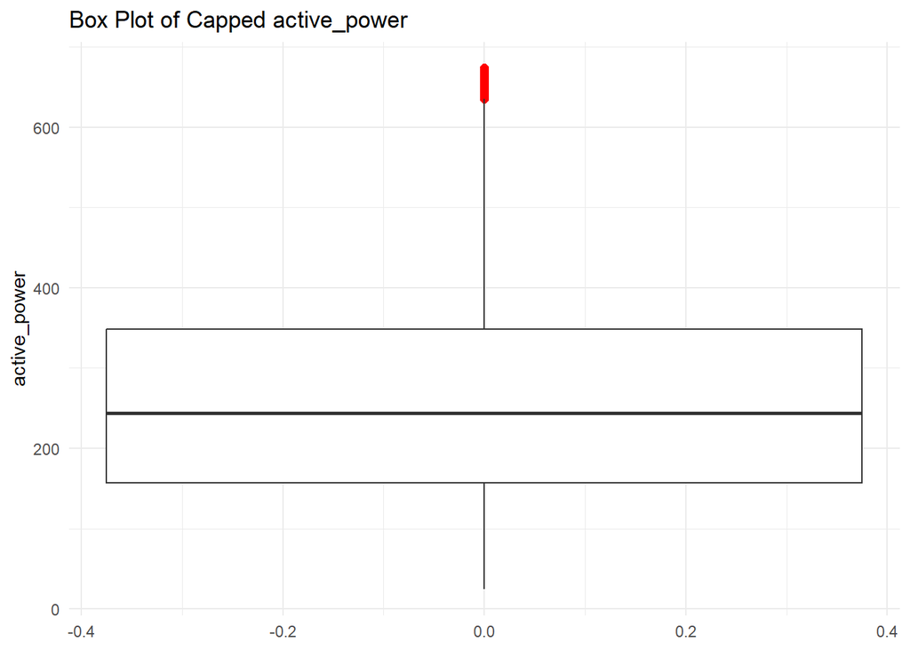

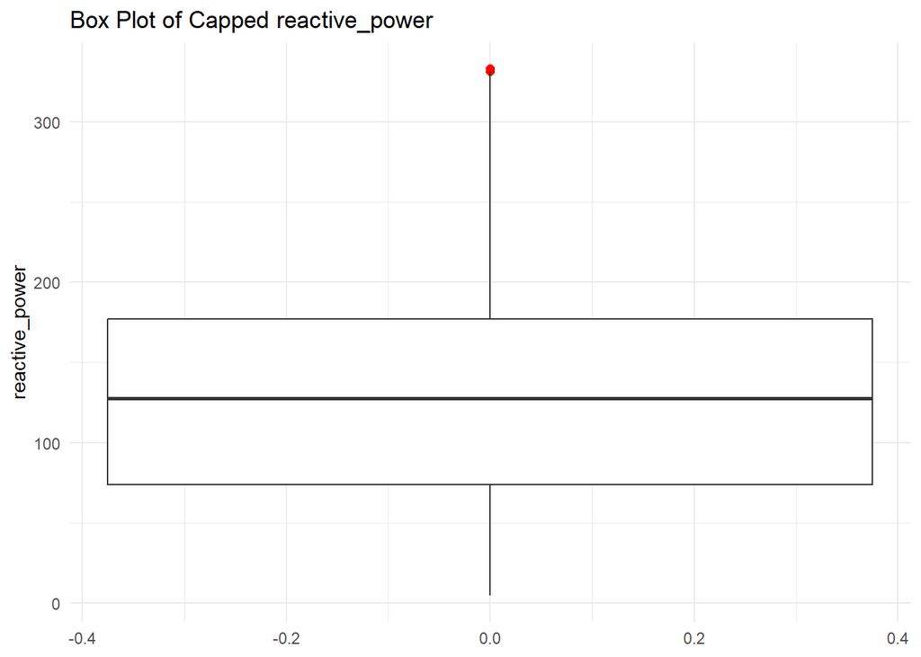

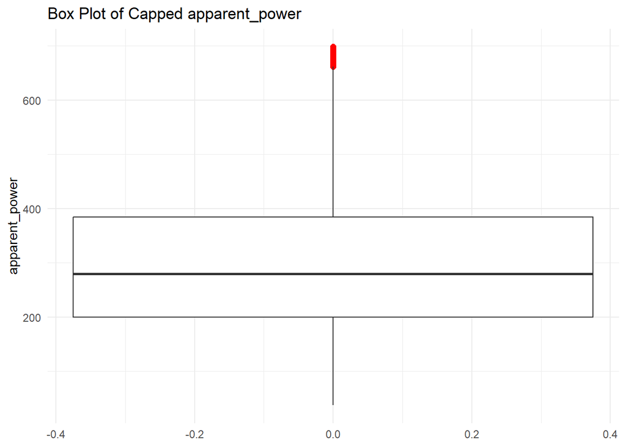

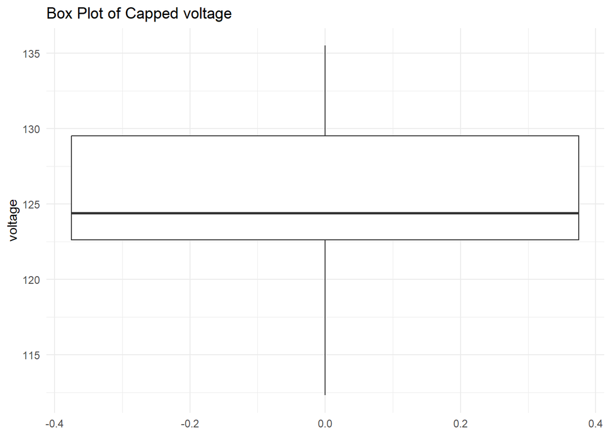

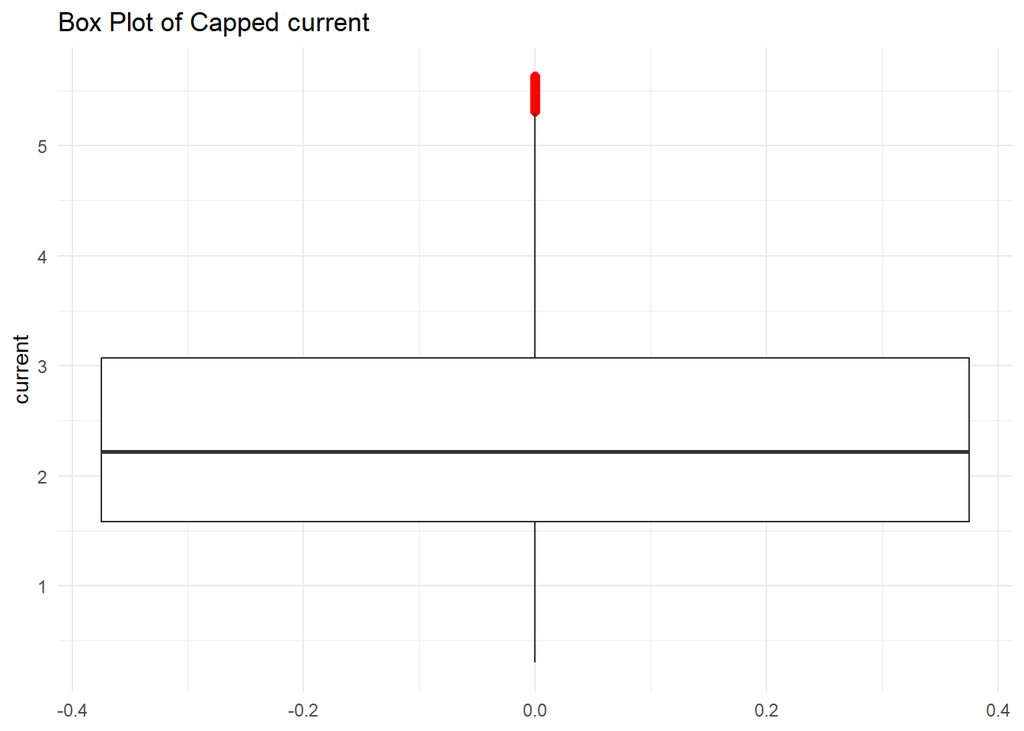

```r
create_plots <- function(data, feature_name) {
  # Box Plot
  box_plot <- ggplot(data, aes_string(y = feature_name)) +
    geom_boxplot(outlier.colour = "red", outlier.shape = 16, outlier.size = 2) +
    ggtitle(paste("Box Plot of Capped", feature_name)) +
    ylab(feature_name) +
    theme_minimal()

  # Print plots
  print(box_plot)

}

# Create visualizations for each power-related variable
for (var in power_variables) {
  create_plots(energy_capped, var)
}
```